# DATA MASTERS - Projekt Kickstarter

# Charakterystyka projektów zakończonych sukcesem i porażką z podziałem na główne kategorie

```python
df_success = df[df["state"] == "successful"] #wyfiltrowanie projektów zakończonych sukcesem
df_failed = df[df["state"] == "failed"] #wyfiltrowanie projektów zakończonych porażką
```

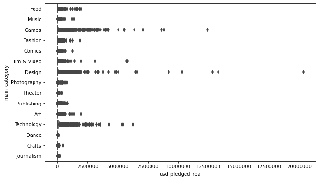

```python
# ZEBRANA KWOTA dla projektów zakończonych SUKCESEM (wykres z wartościami skrajnymi)

x = df_success["usd_pledged_real"]
y = df_success["main_category"]

plt.figure(figsize = (10, 6))
plt.ticklabel_format(style  = 'plain')
ax = sns.boxplot(x, y)

# Widoczna rekordowa zbiórka w kategorii "Design"
```

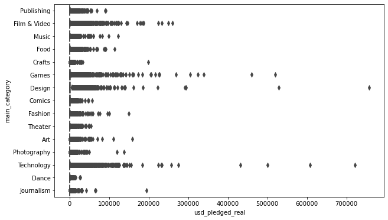

```python
# ZEBRANA KWOTA dla projektów zakończonych PORAŻKĄ (wykres z wartościami skrajnymi)

# wykres z wartościami skrajnymi - boxplot dla każdej kategorii

x = df_failed["usd_pledged_real"]
y = df_failed["main_category"]

plt.figure(figsize = (10, 6))
plt.ticklabel_format(style  = 'plain')
ax = sns.boxplot(x, y)
```

# Rekordowa zbiórka pod względem zebranych pieniędzy

```python
# Rekordowa zbiórka pod względem zebranych pieniędzy

design = df[df["main_category"] == "Design"]
design_successful = design[design["state"] == "successful"]

usd_pledged_column = design_successful["usd pledged"]
usd_pledged_column_max_index = usd_pledged_column.idxmax()
usd_pledged_column_max = design_successful.loc[usd_pledged_column_max_index]

print(usd_pledged_column_max)
```

```
ID                                                        1799979574
name                Pebble Time - Awesome Smartwatch, No Compromises
category                                              Product Design
main_category                                                 Design
currency                                                         USD
deadline                                                  2015-03-28
goal                                                          500000
launched                                         2015-02-24 15:44:42
pledged                                                   2.0339e+07
state                                                     successful
backers                                                        78471
country                                                           US
usd pledged                                               2.0339e+07
usd_pledged_real                                          2.0339e+07
usd_goal_real                                                 500000
Name: 157270, dtype: object
```

[figure not shown]

```python
from IPython.display import Image
Image("PebbleTime.png")
```

Pebble produkowało inteligentne zegarki – o niższej cenie i dłuższej żywotności baterii.

Niestety 7 grudnia 2016 r. firma Pebble oficjalnie ogłosiła, że zostanie zamknięta i nie będzie już produkować ani kontynuować obsługi jakichkolwiek urządzeń.

Własność intelektualna Pebble została zakupiona przez Fitbit, firmę specjalizującą się w monitorowaniu kondycji.

```python
# Usunięcie 1% najwyższych i 1% najniższych wartości zebranych kwot dla zbiórek zakończonych sukcesem

df_success_cut = df_success[(df_success['usd_pledged_real'] > np.quantile(df_success['usd_pledged_real'], 0.01)) &
                            (df_success['usd_pledged_real'] < np.quantile(df_success['usd_pledged_real'], 0.99))]

# Usunięcie 1% najwyższych i 1% najniższych wartości zebranych kwot dla zbiórek zakończonych porażką

df_failed_cut = df_failed[(df_failed['usd_pledged_real'] > np.quantile(df_failed['usd_pledged_real'], 0.01)) &
                          (df_failed['usd_pledged_real'] < np.quantile(df_failed['usd_pledged_real'], 0.99))]
```

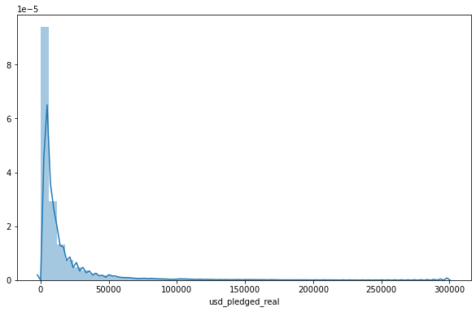

```python
# rozkład zebranych pieniędzy dla zbiórek zakończonych SUKCESEM (bez skrajnych wartości)

fig, ax = plt.subplots(nrows = 1, ncols = 1, figsize = (10, 6))

sns.distplot(df_success_cut['usd_pledged_real'], ax = ax)
```

Większość zbiórek, które osiągnęły sukces zbierała kwoty do $50,000.

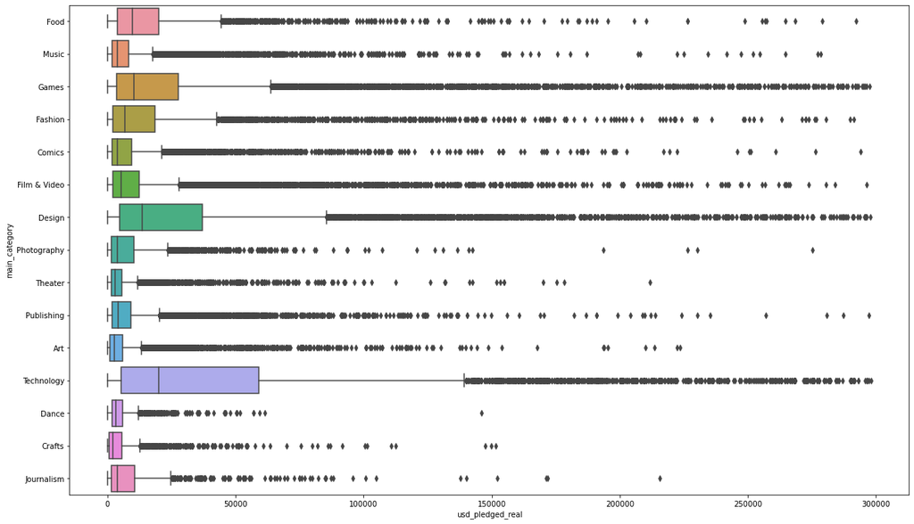

```python
# ZEBRANA KWOTA dla projektów zakończonych SUKCESEM (bez wartości skrajnych)

x = df_success_cut["usd_pledged_real"]
y = df_success_cut["main_category"]

plt.figure(figsize = (20, 12))
plt.ticklabel_format(style  = 'plain')
ax = sns.boxplot(x, y)
```

Kategorie Technology, Design i Games radziły sobie najlepiej pod względem zebranych kwot (dla zbiórek zakończonych sukcesem).

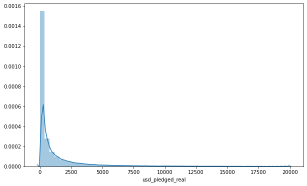

```python
# rozkład zebranych pieniędzy dla zbiórek zakończonych PORAŻKĄ (bez skrajnych wartości)

fig, ax = plt.subplots(nrows = 1, ncols = 1, figsize = (10, 6))

sns.distplot(df_failed_cut['usd_pledged_real'], ax = ax)
```

Większość zbiórek, które nie osiągnęły sukcesu zbierały najczęściej do $2500.

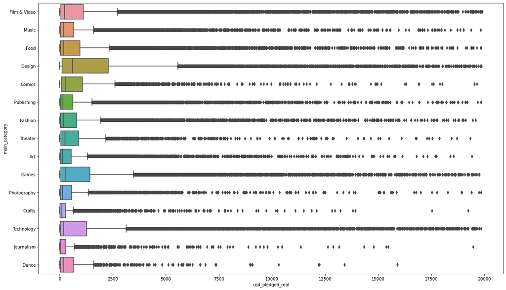

```python
# ZEBRANA KWOTA dla projektów zakończonych PORAŻKĄ (bez wartości skrajnych)

x = df_failed_cut["usd_pledged_real"]
y = df_failed_cut["main_category"]

plt.figure(figsize = (20, 12))
plt.ticklabel_format(style  = 'plain')
ax = sns.boxplot(x, y)
```

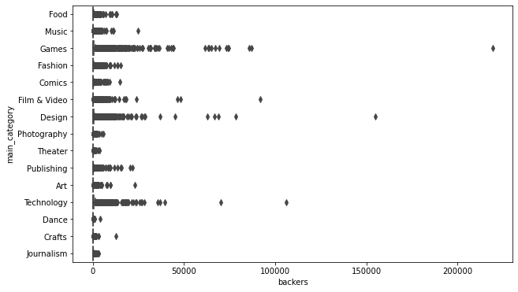

```python
## LICZBA OSÓB WSPIERAJĄCYCH dla projektów zakończonych SUKCESEM
# Widoczna rekordowa zbiórka w kategorii "Games"

x = df_success["backers"]
y = df_success["main_category"]

plt.figure(figsize = (10, 6))
plt.ticklabel_format(style  = 'plain')
ax = sns.boxplot(x, y)
```

# Rekordowa zbiórka zakończona sukcesem pod względem ilości osób wspierających

```python
games = df[df["main_category"] == "Games"]
games_successful = games[games["state"] == "successful"]

backers_column = games_successful["backers"]
backers_column_max_index = backers_column.idxmax()
backers_column_max = games_successful.loc[backers_column_max_index]

print(backers_column_max)
```

```
ID                           1955357092
name                  Exploding Kittens
category                 Tabletop Games
main_category                     Games
currency                            USD
deadline                     2015-02-20
goal                              10000
launched            2015-01-20 19:00:19
pledged                     8.78257e+06
state                        successful
backers                          219382
country                              US
usd pledged                 8.78257e+06
usd_pledged_real            8.78257e+06
usd_goal_real                     10000
Name: 187652, dtype: object
```

[figure not shown]

```python
from IPython.display import Image
Image("ExplodingKittens2.png")
```

Celem zbiórki na Exploding Kittens było $10,000. Cel ten został przekroczony w osiem minut, a 7 dni po otwarciu zbiórka przekroczyła 103,000 osób wspierających, ustanawiając rekord największej liczby sponsorów w historii Kickstartera.

Exploding Kittens jest opisywana jako „strategiczna gra karciana o kotach i zniszczeniu”.

# Analiza sukcesów i porażek - czy zmniejszenie celu zbiórki może zwiększyć jej sukces?

Porównanie zbiórek zakończonych sukcesem i porażką.

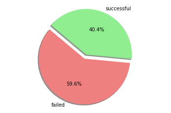

```python
# WYKRES KOŁOWY pokazujący ile kampanii zakończyło się sukcesem i porażką (wyłączając resztę kategorii)

df_fs = df[df['state'].isin(['failed','successful'])] # wyodrębnienie tylko dwóch - sukces i porażka

labels = 'failed', 'successful'
x = df_fs['state'].value_counts()
colors = ['lightcoral', 'lightgreen']
explode = (0.1, 0)  # explode 1st slice

# Plot
plt.pie(x, explode=explode, labels=labels, colors=colors,
autopct='%1.1f%%', shadow=True, startangle=140)

plt.axis('equal')
plt.show()
```

```python
# usunięcie 1% najwyższych wartości dla celu zbiórki ("usd_goal_real")

df_goal_cut = df[(df['usd_goal_real'] < np.quantile(df['usd_goal_real'], 0.99))]

df_goal_cut_success = df_goal_cut[df_goal_cut["state"] == "successful"] # wyfiltrowanie kampanii zakończonych sukcesem
df_goal_cut_failed = df_goal_cut[df_goal_cut["state"] == "failed"] # wyfiltrowanie kampanii zakończonych porażką
```

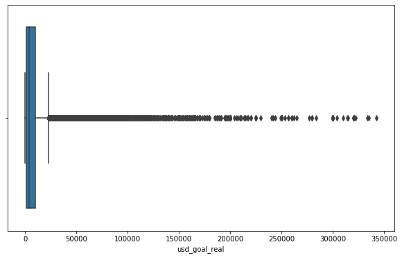

```python
# CEL ZBIÓRKI ($) dla projektów zakończonych SUKCESEM (bez wartości skrajnych)

fig, ax = plt.subplots(nrows = 1, ncols = 1, figsize = (10, 6))
plt.ticklabel_format(style  = 'plain')

sns.boxplot(df_goal_cut_success["usd_goal_real"], ax = ax)
```

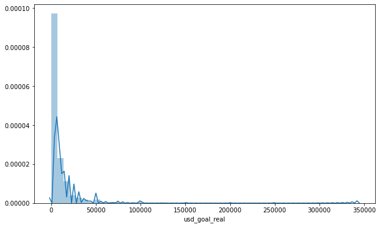

```python
# CEL ZBIÓRKI ($) dla projektów zakończonych SUKCESEM (bez wartości skrajnych)

fig, ax = plt.subplots(nrows = 1, ncols = 1, figsize = (10,6))

sns.distplot(df_goal_cut_success['usd_goal_real'],
             ax = ax)
```

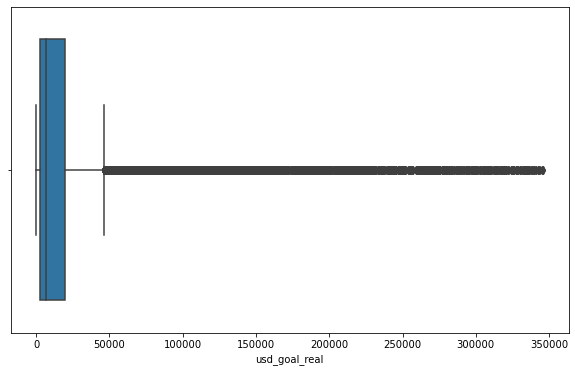

```python
# CEL ZBIÓRKI ($) dla projektów zakończonych PORAŻKĄ (bez wartości skrajnych)

fig, ax = plt.subplots(nrows = 1, ncols = 1, figsize = (10,6))
plt.ticklabel_format(style  = 'plain')

sns.boxplot(df_goal_cut_failed['usd_goal_real'],
             ax = ax)
```

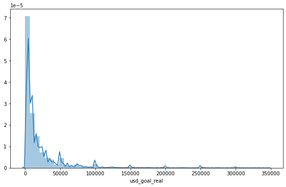

```python
# CEL ZBIÓRKI ($) dla projektów zakończonych PORAŻKĄ (bez wartości skrajnych)

fig, ax = plt.subplots(nrows = 1, ncols = 1, figsize = (10,6))

sns.distplot(df_goal_cut_failed['usd_goal_real'],
             ax = ax)
```

```python
# Czy sukces zbiórki zależy od ustalonej oczekiwanej kwoty zbiórki ("usd_goal_real")?

# Hipoteza zerowa, H0: μx = μy:
H0_goal = "Nie ma statystycznie istotnej różnicy w oczekiwanej kwocie zbiórki między zbiórkami, które osiągnęły sukces i tymi, które osiągnęły porażkę."

# Hipoteza alternatywna kierunkowa, H1 : μx < μy:
H1_goal = "Średnia oczekiwana kwota zbiórki jest istotnie wyższa dla zbiórek, które osiągnęły porażkę."
```

```python
# Test t dla średnich oczekiwanej kwoty zbiórki

x = df_goal_cut.loc[df_goal_cut["state"] == "successful", "usd_goal_real"].values # pobranie wartości dla zbiórek z sukcesem
y = df_goal_cut.loc[df_goal_cut["state"] == "failed", "usd_goal_real"].values # pobranie wartości dla zbiórek z porażką

# wartości dla zbiórek z sukcesem
nx = len(x)
mx = round(st.tmean(x), 2)
sx = round(st.tstd(x), 2)

# wartości dla zbiórek z porażką
ny = len(y)
my = round(st.tmean(y), 2)
sy = round(st.tstd(y), 2)

print (nx, mx, sx)
print(ny, my, sy)
```

```
133749 9017.36 17473.12
194884 19933.92 37107.9
```

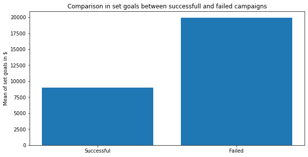

```python
state = ("Successful", "Failed")
means = (9017.36, 19933.92)
sdev = (17473.12, 37107.9)

plt.figure(figsize = (10, 5))
plt.bar(state, means, label = state)
plt.title('Comparison in set goals between successfull and failed campaigns')
plt.ylabel('Mean of set goals in $')
plt.show()
```

```python
print(f"Średnia oczekiwanej kwoty zbiórki dla zbiórek zakończonych sukcesem: {mx} (SD = {sx}).")
print(f"Średnia oczekiwanej kwoty zbiórki dla zbiórek zakończonych porażką: {my} (SD = {sy}).")
```

```
Średnia oczekiwanej kwoty zbiórki dla zbiórek zakończonych sukcesem: 9017.36 (SD = 17473.12).
Średnia oczekiwanej kwoty zbiórki dla zbiórek zakończonych porażką: 19933.92 (SD = 37107.9).
```

```python
alfa = 0.05

l, p1 = st.levene(x, y, center = 'mean') # sprawdzenie, czy wariancje między grupami są równe
print(f"Levene's test of variance equality: statistic = {l}, p-value = {p1}")

if p1 > alfa:
    print("Wariancje między grupami są równe.")
elif p1 <= alfa:
    print("Wariancje między grupami nie są równe.")
```

```
Levene's test of variance equality: statistic = 17663.874255874765, p-value = 0.0
Wariancje między grupami nie są równe.
```

```python
alfa = 0.05

t, p2 = st.ttest_ind(x, y, equal_var = False, nan_policy = 'omit') # dwustronny test studenta (test t)
p2 = p2/2 # podzielenie wartości p (alfa) przez 2, aby uzyskać wartośc testu jednostronnego
print(f"Independent samples t-test: t-statistic = {t}, one-sided p-value = {p2}")

if p2 > alfa:
    print("Hipoteza zerowa nie została odrzucona.")
    print(H0_goal)
elif p2 < alfa:
    print("Hipoteza zerowa została odrzucona na rzecz hipotezy alternatywnej.")
    print(H1_goal)
```

```
Independent samples t-test: t-statistic = -112.9058861130784, one-sided p-value = 0.0
Hipoteza zerowa została odrzucona na rzecz hipotezy alternatywnej.
Średnia oczekiwana kwota zbiórki jest istotnie wyższa dla zbiórek, które osiągnęły porażkę.
```

WNIOSEK: Zbiórka ma większą szansę na sukces, jeśli ma ustalony niższy próg kwoty do zebrania (pledged goal).

# Analiza sukcesów i porażek - czy zmniejszenie czasu zbiórki może zwiększyć jej sukces?

Porównanie zbiórek zakończonych sukcesem i porażką.

```python
H0_duration = "Ustalony czas zbiórki nie różni się między zbiórkami zakończonymi sukcesem i tymi zakończonymi porażkami."
H1_duration = "Zbiórki, które osiągnęły sukces ustaliły krótszy czas zbiórki, niż te, które zakończyły się niepowodzeniem."
```

```python
# Dodanie kolumny "project_duration" w dniach

df['launched'] =  pd.to_datetime(df['launched'])
df['deadline'] =  pd.to_datetime(df['deadline'])
df['project_duration'] = (df['deadline'] - df['launched']).map(lambda x: np.nan if pd.isnull(x) else x.days)
```

```python
# Usunięcie 1% najwyższych wartości dla czas trwania zbiórki ("project_duration")

df_duration_cut = df[(df['project_duration'] < np.quantile(df['project_duration'], 0.99))]

df_duration_cut_success = df_duration_cut[df_duration_cut["state"] == "successful"] # wyfiltrowanie kampanii zakończonych sukcesem
df_duration_cut_failed = df_duration_cut[df_duration_cut["state"] == "failed"] # wyfiltrowanie kampanii zakończonych porażką
```

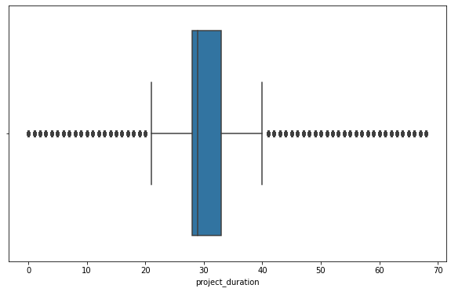

```python
# CZAS ZBIÓRKI (w dniach) dla projektów zakończonych SUKCESEM (bez wartości skrajnych)

fig, ax = plt.subplots(nrows = 1, ncols = 1, figsize = (10, 6))
plt.ticklabel_format(style  = 'plain')

sns.boxplot(df_duration_cut_success['project_duration'],
             ax = ax)
```

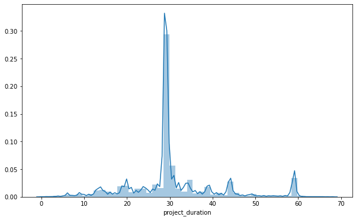

```python
# CZAS ZBIÓRKI (w dniach) dla projektów zakończonych SUKCESEM (bez wartości skrajnych)

fig, ax = plt.subplots(nrows = 1, ncols = 1, figsize = (10, 6))

sns.distplot(df_duration_cut_success['project_duration'],
             ax = ax)
```

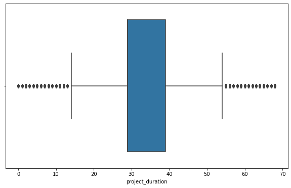

```python
# CZAS ZBIÓRKI (w dniach) dla projektów zakończonych PORAŻKĄ (bez wartości skrajnych)

fig, ax = plt.subplots(nrows = 1, ncols = 1, figsize = (10,6))
plt.ticklabel_format(style  = 'plain')

sns.boxplot(df_duration_cut_failed['project_duration'],
             ax = ax)
```

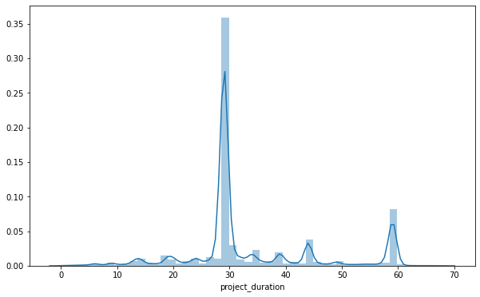

```python
# CZAS ZBIÓRKI (w dniach) dla projektów zakończonych PORAŻKĄ (bez wartości skrajnych)

fig, ax = plt.subplots(nrows = 1, ncols = 1, figsize = (10,6))

sns.distplot(df_duration_cut_failed['project_duration'],
             ax = ax)
```

```python
# Test t dla średnich czasu zbiórki

x = df_duration_cut.loc[df_duration_cut["state"] == "successful", "project_duration"].values # pobranie czasu zbiórki (w dniach) dla zbiórek z sukcesem
y = df_duration_cut.loc[df_duration_cut["state"] == "failed", "project_duration"].values # pobranie czasu zbiórki (w dniach) dla zbiórek z porażką

# wartości dla zbiórek z sukcesem
nx = len(x)
mx = round(st.tmean(x), 2)
sx = round(st.tstd(x), 2)

# wartości dla zbiórek z porażką
ny = len(y)
my = round(st.tmean(y), 2)
sy = round(st.tstd(y), 2)

print (nx, mx, sx)
print(ny, my, sy)
```

```
132662 30.68 10.68
195495 33.62 12.09
```

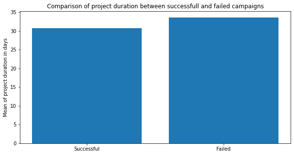

```python
state = ("Successful", "Failed")
means = (30.68, 33.6)
sdev = (10.68, 12.09)

plt.figure(figsize = (10, 5))
plt.bar(state, means, label = state)
plt.title('Comparison of project duration between successfull and failed campaigns')
plt.ylabel('Mean of project duration in days')
plt.show()
```

```python
print(f"Średnia oczekiwanej kwoty zbiórki dla zbiórek zakończonych sukcesem to {mx} (SD = {sx}).")
print(f"Średnia oczekiwanej kwoty zbiórki dla zbiórek zakończonych porażką to {my} (SD = {sy}).")
```

[output not shown]

```python
alfa = 0.05

l, p1 = st.levene(x, y, center = 'mean') # sprawdzenie, czy wariancje między grupami są równe
print(f"Levene's test of variance equality: statistic = {l}, p-value = {p1}")

if p1 > alfa:
    print("Wariancje między grupami są równe.")
elif p1 <= alfa:
    print("Wariancje między grupami nie są równe.")
```

```
Levene's test of variance equality: statistic = 5561.037012262784, p-value = 0.0
Wariancje między grupami nie są równe.
```

```python
alfa = 0.05

t, p2 = st.ttest_ind(x, y, equal_var = False, nan_policy = 'omit') # dwustronny test studenta (test t)
p2 = p2/2 # podzielenie wartości p (alfa) przez 2, aby uzyskać wartośc testu jednostronnego
print(f"Independent samples t-test: t-statistic = {t}, one-sided p-value = {p2}")

if p2 > alfa:
    print("Hipoteza zerowa nie została odrzucona.")
    print(H0_duration)
elif p2 < alfa:
    print("Odrzucenie hipotezy zerowej na rzecz hipotezy alternatywnej.")
    print(H1_duration)
```

```
Independent samples t-test: t-statistic = -73.25483493575776, one-sided p-value = 0.0
Odrzucenie hipotezy zerowej na rzecz hipotezy alternatywnej.
Zbiórki, które osiągnęły sukces ustaliły krótszy czas zbiórki, niż te, które zakończyły się niepowodzeniem.
```

WNIOSEK: Zbiórka ma większą szansę na sukces, jeśli ustala krótszy czas zbiórki.